# Libraries

- import pandas as pd: Imports the Pandas library which is used for data manipulation and analysis.
- import matplotlib.pyplot as plt: Imports the Matplotlib library which is used for data visualization.
- from google.colab import drive: Imports the Google Colaboratory library which allows access to Google Drive files.

# Pie Chart Representation

*fatalities_per_operator.plot(kind='pie', autopct='%1.1f%%', figsize=(12,6))*: Creates a pie chart of the '*fatalities_per_operator*' data, with each operator's percentage of fatalities represented as a slice of the pie. The 'kind' parameter is set to 'pie' to create a pie chart. The 'autopct' parameter specifies the format of the percentage values displayed on the chart. The 'figsize' parameter sets the size of the chart.

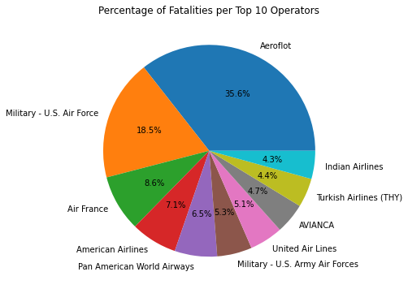

```python
# Import libraries
import pandas as pd
import matplotlib.pyplot as plt

# Mount Google Drive to access the dataset
from google.colab import drive
drive.mount('/content/drive')

# Load data
data = pd.read_csv('/content/Airplane_Crashes_and_Fatalities_Since_1908.csv')

# Create a pie chart of the number of fatalities per operator
fatalities_per_operator = data.groupby('Operator').sum()['Fatalities'].nlargest(10)
fatalities_per_operator.plot(kind='pie', autopct='%1.1f%%', figsize=(12,6))
plt.title('Percentage of Fatalities per Top 10 Operators')
plt.ylabel('')
plt.show()
```

# Scatter Plot Representation

This code uses the Python libraries Pandas and Matplotlib to create a scatter plot of the *number of fatalities versus the number of people aboard for airplane crashes* recorded in a dataset.

- First, Pandas is used to load the dataset Airplane_Crashes_and_Fatalities_Since_1908.csv into a DataFrame named data.
- Next, a scatter plot is created using the plot() method on the data DataFrame. The kind parameter is set to 'scatter' to specify that a scatter plot should be created. The x parameter is set to 'Aboard', which is the column in the DataFrame containing the number of people aboard the airplane. The y parameter is set to 'Fatalities', which is the column in the DataFrame containing the number of fatalities resulting from the airplane crash. The figsize parameter is set to (12,6) to specify the size of the plot.

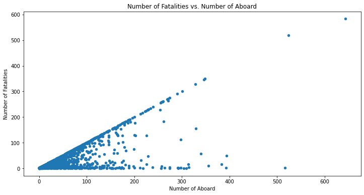

```python
# Import libraries
import pandas as pd
import matplotlib.pyplot as plt

# Load data
data = pd.read_csv('/content/Airplane_Crashes_and_Fatalities_Since_1908.csv')
# Create a scatter plot of the number of fatalities vs. the number of aboard
fatalities_vs_aboard = data.plot(kind='scatter', x='Aboard', y='Fatalities', figsize=(12,6))
plt.title('Number of Fatalities vs. Number of Aboard')
plt.xlabel('Number of Aboard')
plt.ylabel('Number of Fatalities')
plt.show()
```

# Line Chart Representation

[figure not shown]

```python
# Import libraries
import pandas as pd
import matplotlib.pyplot as plt

# Load data
data = pd.read_csv('/content/Airplane_Crashes_and_Fatalities_Since_1908.csv')

# Create a line chart of the number of crashes per year
crashes_per_year = data.groupby('Time').size()
crashes_per_year.plot(kind='line', figsize=(12,6))
plt.title('Number of Airplane Crashes per Year')
plt.xlabel('Year')
plt.ylabel('Number of Crashes')
plt.show()
```

```python
!pip install nbconvert
```

```python
!jupyter nbconvert --to html InfoVis.ipynb
```

[output not shown]

[output cut: 107 more lines]

[output not shown]